# Artificial Intelligence Course, Dr.Fadaei

# CA#4 Machine Learning Intro (Decision Tree & Random Forest Model)

## Parnian Fazel (810198516)

### Goal & Brief Description

In this project, the aim is to get acquainted with machine learning methods by `scikit-learn library`. This project is defined in four phases. In phase zero, I should review and analyze the data. In the first phase, I will get acquainted with preprocessing methods, Then extract features from the text columns. In the second phase using several famous library models, I predict the target and optimize these models. Finally, in the third phase, I become familiar with **Ensemble methods** and compare the results of these types of models with the results of the previous phase.

The dataset provided is a collection of movies and TV series available on the Netflix and Amazon. This dataset contains the features of **title**, **cast**, **country**, **release_year**, **listed_in**, **type(Movie or TV series)**, and **description**. During this project, I will predict the type of movie column.

### Importing Libraries

```python
import numpy as np
import pandas as pd
%matplotlib inline
import matplotlib.pyplot as plt
from collections import Counter
from sklearn import tree
from sklearn.model_selection import train_test_split
from sklearn import tree, metrics, model_selection, preprocessing
from sklearn.model_selection import GridSearchCV
from sklearn.tree import DecisionTreeClassifier
from sklearn.ensemble import RandomForestClassifier
from sklearn.metrics import classification_report, confusion_matrix
from sklearn.feature_extraction.text import CountVectorizer
from sklearn.feature_selection import mutual_info_regression
from sklearn.feature_selection import mutual_info_classif

pd.options.display.max_rows;
```

### Loading the Dataset

Here I read the dataset csv file and store in in a df.

```python
df = pd.read_csv(r"dataset.csv")
df
```

|  | type | title | cast | country | release_year | listed_in | description |
| --- | --- | --- | --- | --- | --- | --- | --- |
| 0 | Movie | Dick Johnson Is Dead | NaN | United States | 2020 | Documentaries | As her father nears the end of his life, filmm... |
| 1 | TV Show | Blood & Water | Ama Qamata, Khosi Ngema, Gail Mabalane, Thaban... | South Africa | 2021 | International TV Shows, TV Dramas, TV Mysteries | After crossing paths at a party, a Cape Town t... |
| 2 | TV Show | Ganglands | Sami Bouajila, Tracy Gotoas, Samuel Jouy, Nabi... | NaN | 2021 | Crime TV Shows, International TV Shows, TV Act... | To protect his family from a powerful drug lor... |
| 3 | TV Show | Jailbirds New Orleans | NaN | NaN | 2021 | Docuseries, Reality TV | Feuds, flirtations and toilet talk go down amo... |
| 4 | TV Show | Kota Factory | Mayur More, Jitendra Kumar, Ranjan Raj, Alam K... | India | 2021 | International TV Shows, Romantic TV Shows, TV ... | In a city of coaching centers known to train I... |
| ... | ... | ... | ... | ... | ... | ... | ... |
| 11054 | TV Show | X-Men: Evolution | Noel Fisher, Vincent Gale, Christopher Judge, ... | United States | 2000 | Action-Adventure, Animation, Kids | X-Men: Evolution features the team as teenager... |
| 11055 | TV Show | Smart Guy | Tahj Mowry, John Jones, Jason Weaver, Essence ... | United States | 1996 | Comedy, Coming of Age, Kids | A genius tries to fit in as a high school soph... |
| 11056 | TV Show | Disney Kirby Buckets | Jacob Bertrand, Mekai Curtis, Cade Sutton, Oli... | United States | 2014 | Action-Adventure, Comedy, Coming of Age | Welcome to Kirby's world! It's rude and sketchy. |
| 11057 | TV Show | Disney Mech-X4 | Nathaniel Potvin, Raymond Cham, Kamran Lucas, ... | Canada | 2016 | Action-Adventure, Comedy, Science Fiction | Ryan discovers his ability to control a giant ... |
| 11058 | TV Show | Imagination Movers | Rich Collins, Dave Poche, Scott Durbin, Scott ... | United States | 2008 | Kids, Music | Rock out with the Imagination Movers, Disney J... |

11059 rows × 7 columns

# Phase 0

One of the first steps in any machine learning project is to observe, recognize and examine the data and the relationship between them.

**Exploratory Data Analysis(EDA):** this is unavoidable and one of the major step to fine-tune the given dataset in a different form of analysis to understand the insights of the key characteristics of various entities of the dataset like columns, rows. Exploratory Data Analysis refers to the critical process of performing initial investigations on data so as to discover patterns,to spot anomalies,to test hypothesis and to check assumption with the help of summary statistics and graphical representations.

## Part 1

Here we get a view some basic structure of dataset and statistical details like percentile, mean, and std of a dataset by `info()` and `describe()` methods of `pandas` library.

```python
df.info()
```

```
<class 'pandas.core.frame.DataFrame'>
RangeIndex: 11059 entries, 0 to 11058
Data columns (total 7 columns):
 #   Column        Non-Null Count  Dtype
---  ------        --------------  -----
 0   type          11059 non-null  object
 1   title         11059 non-null  object
 2   cast          9694 non-null   object
 3   country       8364 non-null   object
 4   release_year  11059 non-null  int64
 5   listed_in     11059 non-null  object
 6   description   11059 non-null  object
dtypes: int64(1), object(6)
memory usage: 604.9+ KB
```

```python
df.describe()
```

|  | release_year |
| --- | --- |
| count | 11059.000000 |
| mean | 2014.209603 |
| std | 8.959517 |
| min | 1925.000000 |
| 25% | 2013.000000 |
| 50% | 2017.000000 |
| 75% | 2019.000000 |
| max | 2021.000000 |

## Part 2

Here we are to get some information about the missing values of the dataset. For this purpose I use `isna()` method. isna() function is used to detect missing values. It return a boolean same-sized object indicating if the values are NA.

```python
df.isna().sum()
```

```
type               0
title              0
cast            1365
country         2695
release_year       0
listed_in          0
description        0
dtype: int64
```

Now I find what percentage of values in a column is missing.

```python
null_values = df.isna().sum() / len(df) * 100
null_values
```

```
type             0.000000
title            0.000000
cast            12.342888
country         24.369292
release_year     0.000000
listed_in        0.000000
description      0.000000
dtype: float64
```

# Phase 1

## Pre-Processing

Data preprocessing in Machine Learning is a crucial step that helps enhance the quality of data to promote the extraction of meaningful insights from the data. Typically, real-world data is incomplete, inconsistent, inaccurate.

## Part 1: Handling Missing Values

Here we stusy two ways of handling missing values.:

- **Deleting Rows:** This method commonly used to handle the null values. Here, we either delete a particular row if it has a null value for a particular feature and a particular column if it has more than 70-75% of missing values. This method is advised only when there are enough samples in the data set. One has to make sure that after we have deleted the data, there is no addition of bias. Removing the data will lead to loss of information which will not give the expected results while predicting the output.
- **Mean/Median/Mode Imputation:** This strategy is one of the most common used approaches in hadeling missing numeric values. We can calculate the mean, median or mode of the feature and replace it with the missing values. This is an approximation which can add variance to the data set. But the loss of the data can be negated by this method which yields better results compared to removal of rows and columns.

## Part 2: Normalization & Standardization

Differences in the scales across input variables may increase the difficulty of the problem being modeled. Data transformation is one of the fundamental steps in the part of data processing. In practice, we often encounter different types of variables in the same dataset. A significant issue is that the range of the variables may differ a lot. Using the original scale may put more weights on the variables with a large range. In order to deal with this problem, we need to apply the technique of features rescaling to independent variables or features of data in the step of data pre-processing.

- **Normalization:** Normalization is a scaling technique in which values are shifted and rescaled so that they end up **ranging between 0 and 1**. It is also known as Min-Max scaling.
- **Standardisation:** The result of standardization (or Z-score normalization) is that the features will be rescaled to ensure the **mean** and the **standard deviation** to be **0** and **1**, respectively.

Here is the formula:

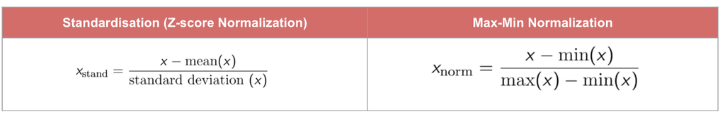

## Part 3: Handling Categorical Data

Most machine learning algorithms cannot handle categorical variables unless we convert them to numerical values. In the given dataset in this assignment, the **conutry**, **cast**, and **type** features are nominal(categorical). The two most used methods are:

- **One-hot Encoding:** In this method, each category is mapped to a vector that contains 1 and 0 denoting the presence or absence of the feature. The number of vectors depends on the number of categories for features.
- **Label Encoding:** In label encoding, each category is assigned a value from 1 through N where N is the number of categories for the feature. There is no relation or order between these assignments.

In this assignment there is not a big difference between these two approaches; I used label encoding method since I think it is more simple and to avoid any inefficencies. I label cast and country columns in the following parts but I label type column here.

```python
type_before_labeling = df["type"]
df["type"] = df["type"].map({"TV Show": 0, "Movie": 1})
df.head()
```

|  | type | title | cast | country | release_year | listed_in | description |
| --- | --- | --- | --- | --- | --- | --- | --- |
| 0 | 1 | Dick Johnson Is Dead | NaN | United States | 2020 | Documentaries | As her father nears the end of his life, filmm... |
| 1 | 0 | Blood & Water | Ama Qamata, Khosi Ngema, Gail Mabalane, Thaban... | South Africa | 2021 | International TV Shows, TV Dramas, TV Mysteries | After crossing paths at a party, a Cape Town t... |
| 2 | 0 | Ganglands | Sami Bouajila, Tracy Gotoas, Samuel Jouy, Nabi... | NaN | 2021 | Crime TV Shows, International TV Shows, TV Act... | To protect his family from a powerful drug lor... |
| 3 | 0 | Jailbirds New Orleans | NaN | NaN | 2021 | Docuseries, Reality TV | Feuds, flirtations and toilet talk go down amo... |
| 4 | 0 | Kota Factory | Mayur More, Jitendra Kumar, Ranjan Raj, Alam K... | India | 2021 | International TV Shows, Romantic TV Shows, TV ... | In a city of coaching centers known to train I... |

As it is shown the **Movie** type is labeled as 1 and **TV Show** is labeled as 0.

## Part 4: Handling series of data in a cell

I the given dataset the `listed_in` and `country` columns has series of data. There could be 2 ways we can handle this.

The **first** approach is to add 3 columns as `genre1`, `genre2` and `genre3` to dataset and then fill these columns with the 3 first genres of each row (Movie or TV Show). In this case for movies which does not have less than 3 genres, I filled the rest genre columns as a duplicate of the first genre(each movie has at least one genre since we saw in phase zero that this column has not any missing values). Note that since the majority of movies has 3 genres I considered 3 columns but up to 5 columns could be added for this aim.

The **second** one I want to mention is feature extraction and to consider a column for each genre and fill these column with 0 or 1 if the movie in that genre or not, respectively. I emplyed the first approach, since in my oppinion the second way could cause some inefficencies and was more complex.

```python
genres_for_each_row  = []
for genres in df["listed_in"]:
    genres_for_each_row.append(genres.replace(", ", ",").split(','))
df['genre1'] = [genres_for_each_row[i][0] for i in df.index]
df['genre2'] = [(genres_for_each_row[i][1] if (len(genres_for_each_row[i]) > 1) else genres_for_each_row[i][0])\
                for i in df.index]
df['genre3'] = [(genres_for_each_row[i][2] if (len(genres_for_each_row[i]) > 2) else genres_for_each_row[i][0])\
                for i in df.index]
```

```python
df.tail()
```

|  | type | title | cast | country | release_year | listed_in | description | genre1 | genre2 | genre3 |
| --- | --- | --- | --- | --- | --- | --- | --- | --- | --- | --- |
| 11054 | 0 | X-Men: Evolution | Noel Fisher, Vincent Gale, Christopher Judge, ... | United States | 2000 | Action-Adventure, Animation, Kids | X-Men: Evolution features the team as teenager... | Action-Adventure | Animation | Kids |
| 11055 | 0 | Smart Guy | Tahj Mowry, John Jones, Jason Weaver, Essence ... | United States | 1996 | Comedy, Coming of Age, Kids | A genius tries to fit in as a high school soph... | Comedy | Coming of Age | Kids |
| 11056 | 0 | Disney Kirby Buckets | Jacob Bertrand, Mekai Curtis, Cade Sutton, Oli... | United States | 2014 | Action-Adventure, Comedy, Coming of Age | Welcome to Kirby's world! It's rude and sketchy. | Action-Adventure | Comedy | Coming of Age |
| 11057 | 0 | Disney Mech-X4 | Nathaniel Potvin, Raymond Cham, Kamran Lucas, ... | Canada | 2016 | Action-Adventure, Comedy, Science Fiction | Ryan discovers his ability to control a giant ... | Action-Adventure | Comedy | Science Fiction |
| 11058 | 0 | Imagination Movers | Rich Collins, Dave Poche, Scott Durbin, Scott ... | United States | 2008 | Kids, Music | Rock out with the Imagination Movers, Disney J... | Kids | Music | Kids |

As I mentioned in part 3, `listed_in` feature is categorical and need to be encoded. For this purpose I gathedred all genres in 3 columns of genres and mapped them to numbers so that each genre in the every column of genres has the same mapping value.

```python
from sklearn import preprocessing
le = preprocessing.LabelEncoder()
le.fit(df["genre1"].append(df["genre2"]).append(df["genre3"]))
le_name_mapping = dict(zip(le.classes_, le.transform(le.classes_)))
```

```python
df['genre1'] = df['genre1'].map(le_name_mapping)
df['genre2'] = df['genre2'].map(le_name_mapping)
df['genre3'] = df['genre3'].map(le_name_mapping)
df.head()
```

|  | type | title | cast | country | release_year | listed_in | description | genre1 | genre2 | genre3 |
| --- | --- | --- | --- | --- | --- | --- | --- | --- | --- | --- |
| 0 | 1 | Dick Johnson Is Dead | NaN | United States | 2020 | Documentaries | As her father nears the end of his life, filmm... | 22 | 22 | 22 |
| 1 | 0 | Blood & Water | Ama Qamata, Khosi Ngema, Gail Mabalane, Thaban... | South Africa | 2021 | International TV Shows, TV Dramas, TV Mysteries | After crossing paths at a party, a Cape Town t... | 40 | 79 | 81 |
| 2 | 0 | Ganglands | Sami Bouajila, Tracy Gotoas, Samuel Jouy, Nabi... | NaN | 2021 | Crime TV Shows, International TV Shows, TV Act... | To protect his family from a powerful drug lor... | 20 | 40 | 77 |
| 3 | 0 | Jailbirds New Orleans | NaN | NaN | 2021 | Docuseries, Reality TV | Feuds, flirtations and toilet talk go down amo... | 24 | 58 | 24 |
| 4 | 0 | Kota Factory | Mayur More, Jitendra Kumar, Ranjan Raj, Alam K... | India | 2021 | International TV Shows, Romantic TV Shows, TV ... | In a city of coaching centers known to train I... | 40 | 61 | 78 |

```python
all_countries = []
countries_for_each_row = []
df['country'] = df['country'].fillna(0)
for countries in df["country"]:
    if countries == 0:
        countries_for_each_row.append([])
    else:
        countries_for_each_row.append(countries.replace(", ", ",").split(','))
        all_countries.extend(countries.replace(", ", ",").split(','))
most_frequent_countries = [x[0] for x in Counter(all_countries).most_common(2)]


df['country1'] = [(countries_for_each_row[i][0] if (len(countries_for_each_row[i]) > 0)\
                   else most_frequent_countries[0]) for i in df.index]
df['country2'] = [(countries_for_each_row[i][1] if (len(countries_for_each_row[i]) > 1)\
                   else countries_for_each_row[i][0] if (len(countries_for_each_row[i]) > 0)\
                   else most_frequent_countries[0]) for i in df.index]


le = preprocessing.LabelEncoder()
le.fit(df["country1"].append(df["country2"]))
le_name_mapping = dict(zip(le.classes_, le.transform(le.classes_)))
df['country1'] = df['country1'].map(le_name_mapping)
df['country2'] = df['country2'].map(le_name_mapping)
```

Now I merge the `title` and `description` columns and add them into the new `title_description` column since they could give not so different information. And finally I drop the `country`, `listed_in`, `title` and `description` columns.

```python
df['title_description'] = df['title'] + ' ' + df['description']
df = df.drop(['country', 'listed_in', 'title', 'description'], axis=1)
```

Here is the dataset till now:

```python
df
```

|  | type | cast | release_year | genre1 | genre2 | genre3 | country1 | country2 | title_description |
| --- | --- | --- | --- | --- | --- | --- | --- | --- | --- |
| 0 | 1 | NaN | 2020 | 22 | 22 | 22 | 100 | 100 | Dick Johnson Is Dead As her father nears the e... |
| 1 | 0 | Ama Qamata, Khosi Ngema, Gail Mabalane, Thaban... | 2021 | 40 | 79 | 81 | 86 | 86 | Blood & Water After crossing paths at a party,... |
| 2 | 0 | Sami Bouajila, Tracy Gotoas, Samuel Jouy, Nabi... | 2021 | 20 | 40 | 77 | 100 | 100 | Ganglands To protect his family from a powerfu... |
| 3 | 0 | NaN | 2021 | 24 | 58 | 24 | 100 | 100 | Jailbirds New Orleans Feuds, flirtations and t... |
| 4 | 0 | Mayur More, Jitendra Kumar, Ranjan Raj, Alam K... | 2021 | 40 | 61 | 78 | 38 | 38 | Kota Factory In a city of coaching centers kno... |
| ... | ... | ... | ... | ... | ... | ... | ... | ... | ... |
| 11054 | 0 | Noel Fisher, Vincent Gale, Christopher Judge, ... | 2000 | 2 | 5 | 41 | 100 | 100 | X-Men: Evolution X-Men: Evolution features the... |
| 11055 | 0 | Tahj Mowry, John Jones, Jason Weaver, Essence ... | 1996 | 18 | 19 | 41 | 100 | 100 | Smart Guy A genius tries to fit in as a high s... |
| 11056 | 0 | Jacob Bertrand, Mekai Curtis, Cade Sutton, Oli... | 2014 | 2 | 18 | 19 | 100 | 100 | Disney Kirby Buckets Welcome to Kirby's world!... |
| 11057 | 0 | Nathaniel Potvin, Raymond Cham, Kamran Lucas, ... | 2016 | 2 | 18 | 64 | 17 | 17 | Disney Mech-X4 Ryan discovers his ability to c... |
| 11058 | 0 | Rich Collins, Dave Poche, Scott Durbin, Scott ... | 2008 | 41 | 50 | 41 | 100 | 100 | Imagination Movers Rock out with the Imaginati... |

11059 rows × 9 columns

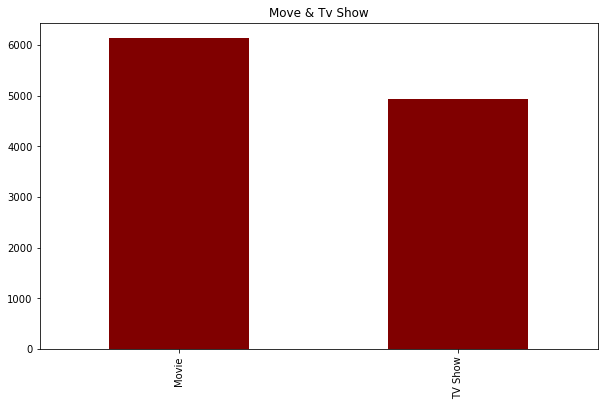

```python
fig = plt.figure()
fig.set_figheight(6)
fig.set_figwidth(10)
plt.title('Move & Tv Show')
type_before_labeling.value_counts().plot.bar(color ='maroon')
plt.show()
```

## Feature Extraction

Feature extraction is a process of dimensionality reduction by which an initial set of raw data is reduced to more manageable groups for processing. A characteristic of these large data sets is a large number of variables that require a lot of computing resources to process. Feature extraction is the name for methods that select and /or combine variables into features, effectively reducing the amount of data that must be processed, while still accurately and completely describing the original data set. Feature extraction increases the accuracy of learned models by extracting features from the input data. This phase of the general framework reduces the dimensionality of data by removing the redundant data. Of course, it increases training and inference speed.

The process of feature extraction is useful when you need to reduce the number of resources needed for processing without losing important or relevant information. Feature extraction can also reduce the amount of redundant data for a given analysis. Also, the reduction of the data and the machine’s efforts in building variable combinations (features) facilitate the speed of learning and generalization steps in the machine learning process.

Since machine learning algorithms cannot work on the raw text directly. So, we need some feature extraction techniques to convert text into a matrix(or vector) of features. We need to extract features for the `cast` and `title-description` columns.

I studied 2 approaches for extracting features:

- **Count Vectorizer:** Counting is a approach to represent text as a numeric feature. it checks if a word exists or not, it also checks how many times a word appeared. In sklearn we can use CountVectorizer to transform the text. An encoded vector is returned with a length of the entire vocabulary and an integer count for the number of times each word appeared in the document. I used this method for `cast` column.
- **TF-IDF:** it stands for *term frequency-inverse document frequency*. We saw that Counting approach assigns weights to the words based on their frequency and it’s obvious that frequently occurring words will have higher weights. But these words might not be important as other words. TF-IDF assigns more weight to less frequently occurring words rather than frequently occurring ones. It is based on the assumption that less frequently occurring words are more important. This encoding normalizes the frequency of tokens in a document with respect to the rest of the corpus. I employed this method in `title-description` column.

Here I will extract **10 features** from the `cast` column by `CountVectorizer()` method in `sklearn.feature_extraction.text`. For values which are missing in cast column, I considered 3 most frequent casts in dataset for them.

```python
# from collections import Counter
all_casts = []
casts_with_non_null_values = df["cast"].dropna()
for casts in casts_with_non_null_values:
    all_casts.extend(casts.replace(" ", "").split(','))
most_frequent_casts = [x[0] for x in Counter(all_casts).most_common(3)]
df["cast"].fillna(value = ",".join(most_frequent_casts), inplace = True)

def cast_preprocess(x):
    x = x.replace(" ", "")
    x = x.replace("-", "")
    x = x.replace(".", "")
    return x.lower()

df["cast"] = df["cast"].apply(np.vectorize(cast_preprocess))

# from sklearn.feature_extraction.text import CountVectorizer
vectorizer = CountVectorizer(max_features = 10, stop_words="english", analyzer='word')
vectorized = vectorizer.fit_transform(df["cast"])
wordFeatures_countvectorizer_cast = pd.DataFrame(vectorized.toarray() , index = df.index,\
                                             columns = vectorizer.get_feature_names())
wordFeatures_countvectorizer_cast
```

|  | akshaykumar | anupamkher | fredtatasciore | julietejwani | naseeruddinshah | ompuri | rupabhimani | shahrukhkhan | takahirosakurai | yukikaji |
| --- | --- | --- | --- | --- | --- | --- | --- | --- | --- | --- |
| 0 | 0 | 1 | 0 | 1 | 0 | 0 | 0 | 1 | 0 | 0 |
| 1 | 0 | 0 | 0 | 0 | 0 | 0 | 0 | 0 | 0 | 0 |
| 2 | 0 | 0 | 0 | 0 | 0 | 0 | 0 | 0 | 0 | 0 |
| 3 | 0 | 1 | 0 | 1 | 0 | 0 | 0 | 1 | 0 | 0 |
| 4 | 0 | 0 | 0 | 0 | 0 | 0 | 0 | 0 | 0 | 0 |
| ... | ... | ... | ... | ... | ... | ... | ... | ... | ... | ... |
| 11054 | 0 | 0 | 0 | 0 | 0 | 0 | 0 | 0 | 0 | 0 |
| 11055 | 0 | 0 | 0 | 0 | 0 | 0 | 0 | 0 | 0 | 0 |
| 11056 | 0 | 0 | 0 | 0 | 0 | 0 | 0 | 0 | 0 | 0 |
| 11057 | 0 | 0 | 0 | 0 | 0 | 0 | 0 | 0 | 0 | 0 |
| 11058 | 0 | 0 | 0 | 0 | 0 | 0 | 0 | 0 | 0 | 0 |

11059 rows × 10 columns

Now I extract 40 features from `title_description` column by `TfidfVectorizer()` method in sklearn library.

```python
from sklearn.feature_extraction.text import TfidfVectorizer
vectorizer = TfidfVectorizer(max_features = 40, stop_words="english", analyzer='word')
vectorized = vectorizer.fit_transform(df["title_description"])
wordFeaturesTF_IDF_title_description = pd.DataFrame(vectorized.toarray() , index = df.index ,\
                                                    columns = vectorizer.get_feature_names())
wordFeaturesTF_IDF_title_description
```

|  | best | city | comedy | day | documentary | family | father | finds | friends | girl | ... | time | town | true | war | way | woman | world | year | years | young |
| --- | --- | --- | --- | --- | --- | --- | --- | --- | --- | --- | --- | --- | --- | --- | --- | --- | --- | --- | --- | --- | --- |
| 0 | 0.0 | 0.000000 | 0.0 | 0.0 | 0.0 | 0.000000 | 0.630026 | 0.0 | 0.000000 | 0.0 | ... | 0.0 | 0.00000 | 0.0 | 0.000000 | 0.0 | 0.0 | 0.000000 | 0.0 | 0.0 | 0.0 |
| 1 | 0.0 | 0.000000 | 0.0 | 0.0 | 0.0 | 0.000000 | 0.000000 | 0.0 | 0.000000 | 0.0 | ... | 0.0 | 0.73733 | 0.0 | 0.000000 | 0.0 | 0.0 | 0.000000 | 0.0 | 0.0 | 0.0 |
| 2 | 0.0 | 0.000000 | 0.0 | 0.0 | 0.0 | 0.487241 | 0.000000 | 0.0 | 0.000000 | 0.0 | ... | 0.0 | 0.00000 | 0.0 | 0.625366 | 0.0 | 0.0 | 0.000000 | 0.0 | 0.0 | 0.0 |
| 3 | 0.0 | 0.000000 | 0.0 | 0.0 | 0.0 | 0.000000 | 0.000000 | 0.0 | 0.000000 | 0.0 | ... | 0.0 | 0.00000 | 0.0 | 0.000000 | 0.0 | 0.0 | 0.000000 | 0.0 | 0.0 | 0.0 |
| 4 | 0.0 | 0.665388 | 0.0 | 0.0 | 0.0 | 0.000000 | 0.000000 | 0.0 | 0.571631 | 0.0 | ... | 0.0 | 0.00000 | 0.0 | 0.000000 | 0.0 | 0.0 | 0.000000 | 0.0 | 0.0 | 0.0 |
| ... | ... | ... | ... | ... | ... | ... | ... | ... | ... | ... | ... | ... | ... | ... | ... | ... | ... | ... | ... | ... | ... |
| 11054 | 0.0 | 0.000000 | 0.0 | 0.0 | 0.0 | 0.000000 | 0.000000 | 0.0 | 0.000000 | 0.0 | ... | 0.0 | 0.00000 | 0.0 | 0.000000 | 0.0 | 0.0 | 0.604626 | 0.0 | 0.0 | 0.0 |
| 11055 | 0.0 | 0.000000 | 0.0 | 0.0 | 0.0 | 0.000000 | 0.000000 | 0.0 | 0.000000 | 0.0 | ... | 0.0 | 0.00000 | 0.0 | 0.000000 | 0.0 | 0.0 | 0.000000 | 0.0 | 0.0 | 0.0 |
| 11056 | 0.0 | 0.000000 | 0.0 | 0.0 | 0.0 | 0.000000 | 0.000000 | 0.0 | 0.000000 | 0.0 | ... | 0.0 | 0.00000 | 0.0 | 0.000000 | 0.0 | 0.0 | 1.000000 | 0.0 | 0.0 | 0.0 |
| 11057 | 0.0 | 0.000000 | 0.0 | 0.0 | 0.0 | 0.000000 | 0.000000 | 0.0 | 0.000000 | 0.0 | ... | 0.0 | 0.00000 | 0.0 | 0.000000 | 0.0 | 0.0 | 0.000000 | 0.0 | 0.0 | 0.0 |
| 11058 | 0.0 | 0.000000 | 0.0 | 0.0 | 0.0 | 0.000000 | 0.000000 | 0.0 | 0.000000 | 0.0 | ... | 0.0 | 0.00000 | 0.0 | 0.000000 | 0.0 | 0.0 | 0.000000 | 0.0 | 0.0 | 0.0 |

11059 rows × 40 columns

Finally, I concat the result of extracting features to the main data frame and drop `cast` and `title_description` columns because we extracted features from them and we do not need them anymore.

```python
result = pd.concat([wordFeatures_countvectorizer_cast, wordFeaturesTF_IDF_title_description], axis=1)
df = pd.concat([df, result], axis=1)
df = df.drop(['cast', 'title_description'], axis=1)
df.head()
```

|  | type | release_year | genre1 | genre2 | genre3 | country1 | country2 | akshaykumar | anupamkher | fredtatasciore | ... | time | town | true | war | way | woman | world | year | years | young |
| --- | --- | --- | --- | --- | --- | --- | --- | --- | --- | --- | --- | --- | --- | --- | --- | --- | --- | --- | --- | --- | --- |
| 0 | 1 | 2020 | 22 | 22 | 22 | 100 | 100 | 0 | 1 | 0 | ... | 0.0 | 0.00000 | 0.0 | 0.000000 | 0.0 | 0.0 | 0.0 | 0.0 | 0.0 | 0.0 |
| 1 | 0 | 2021 | 40 | 79 | 81 | 86 | 86 | 0 | 0 | 0 | ... | 0.0 | 0.73733 | 0.0 | 0.000000 | 0.0 | 0.0 | 0.0 | 0.0 | 0.0 | 0.0 |
| 2 | 0 | 2021 | 20 | 40 | 77 | 100 | 100 | 0 | 0 | 0 | ... | 0.0 | 0.00000 | 0.0 | 0.625366 | 0.0 | 0.0 | 0.0 | 0.0 | 0.0 | 0.0 |
| 3 | 0 | 2021 | 24 | 58 | 24 | 100 | 100 | 0 | 1 | 0 | ... | 0.0 | 0.00000 | 0.0 | 0.000000 | 0.0 | 0.0 | 0.0 | 0.0 | 0.0 | 0.0 |
| 4 | 0 | 2021 | 40 | 61 | 78 | 38 | 38 | 0 | 0 | 0 | ... | 0.0 | 0.00000 | 0.0 | 0.000000 | 0.0 | 0.0 | 0.0 | 0.0 | 0.0 | 0.0 |

5 rows × 57 columns

By **increasing** the number of extracted features more than I did, the model could **overfit**, cause **inefficiency** and **loss of performance**. Although, extracting good features with normal number, could make a better model and classification.

## Relationships Between Features

We study the relation between features by **Information gain** in order to find better features which could help us get a better prediction.

According to *Artificial Intelligence: A modern Approach*, The **Information Gain** from the attribute test is the difference between the original information requirment and the new requirment.

**Entropy** is an information theory metric that measures the impurity or uncertainty in a group of observations. It determines how a decision tree chooses to split data.

Definition of **information gain** is as a measure of how much information a feature provides about a class. Information gain helps to determine the order of attributes in the nodes of a decision tree. The main node is referred to as the parent node, whereas sub-nodes are known as child nodes. We can use information gain to determine how good the splitting of nodes in a decision tree.

$Gain = E_{parent} − E_{children}$

For this purpose I used the `mutual_info_classif()` methon in sklearn library.

```python
gain = mutual_info_classif(df.drop(['type'], axis=1), df["type"])
gain = pd.Series(gain)
gain.index = df.drop(['type'], axis=1).columns
gain.sort_values(ascending = False, inplace = True)

gain
```

```
genre2             0.686548
genre1             0.685033
genre3             0.684906
country2           0.078678
country1           0.074943
series             0.035512
release_year       0.029195
anupamkher         0.014079
friends            0.013389
special            0.012011
man                0.011540
world              0.011466
girl               0.011244
new                0.011078
old                0.009446
team               0.009406
julietejwani       0.008681
akshaykumar        0.008140
fredtatasciore     0.007806
documentary        0.006786
shahrukhkhan       0.006759
finds              0.006271
woman              0.005525
son                0.004920
rupabhimani        0.004549
yukikaji           0.004068
day                0.002959
family             0.001812
stories            0.000736
save               0.000558
time               0.000281
town               0.000191
city               0.000000
ompuri             0.000000
best               0.000000
naseeruddinshah    0.000000
takahirosakurai    0.000000
young              0.000000
comedy             0.000000
father             0.000000
year               0.000000
way                0.000000
war                0.000000
true               0.000000
takes              0.000000
story              0.000000
secret             0.000000
school             0.000000
love               0.000000
lives              0.000000
life               0.000000
home               0.000000
high               0.000000
years              0.000000
group              0.000000
help               0.000000
dtype: float64
```

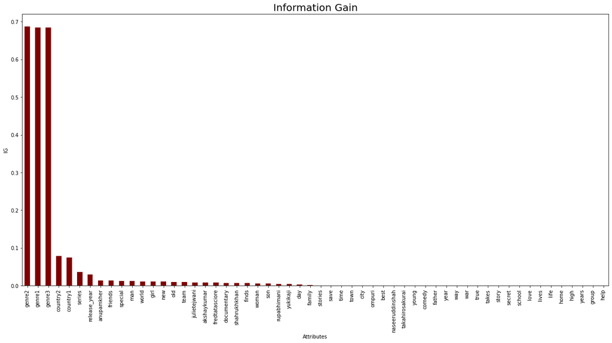

```python
fig = plt.figure()
fig.set_figheight(10)
fig.set_figwidth(21)
plt.title('Information Gain', fontsize=20)
plt.xlabel('Attributes')
plt.ylabel('IG')
gain.plot.bar(color ='maroon')
plt.show()
```

As we can see from the plot above the genre and country attributes has the highest informaion gain value. As mentioned before, Information gain helps to determine the order of attributes in the nodes of a decision tree, so an attribute with the highest information gain from a set should be selected as the parent (root) node.

```python
df.head()
```

|  | type | release_year | genre1 | genre2 | genre3 | country1 | country2 | akshaykumar | anupamkher | fredtatasciore | ... | time | town | true | war | way | woman | world | year | years | young |
| --- | --- | --- | --- | --- | --- | --- | --- | --- | --- | --- | --- | --- | --- | --- | --- | --- | --- | --- | --- | --- | --- |
| 0 | 1 | 2020 | 22 | 22 | 22 | 100 | 100 | 0 | 1 | 0 | ... | 0.0 | 0.00000 | 0.0 | 0.000000 | 0.0 | 0.0 | 0.0 | 0.0 | 0.0 | 0.0 |
| 1 | 0 | 2021 | 40 | 79 | 81 | 86 | 86 | 0 | 0 | 0 | ... | 0.0 | 0.73733 | 0.0 | 0.000000 | 0.0 | 0.0 | 0.0 | 0.0 | 0.0 | 0.0 |
| 2 | 0 | 2021 | 20 | 40 | 77 | 100 | 100 | 0 | 0 | 0 | ... | 0.0 | 0.00000 | 0.0 | 0.625366 | 0.0 | 0.0 | 0.0 | 0.0 | 0.0 | 0.0 |
| 3 | 0 | 2021 | 24 | 58 | 24 | 100 | 100 | 0 | 1 | 0 | ... | 0.0 | 0.00000 | 0.0 | 0.000000 | 0.0 | 0.0 | 0.0 | 0.0 | 0.0 | 0.0 |
| 4 | 0 | 2021 | 40 | 61 | 78 | 38 | 38 | 0 | 0 | 0 | ... | 0.0 | 0.00000 | 0.0 | 0.000000 | 0.0 | 0.0 | 0.0 | 0.0 | 0.0 | 0.0 |

5 rows × 57 columns

## Phase 2: Prediction and Optimiztaion

first I split the dataset into train data and test data by `train_test_split()` methon in sklearn library.

The train-test split is a technique for evaluating the performance of a machine learning algorithm. It can be used for classification or regression problems and can be used for any supervised learning algorithm. The procedure involves taking a dataset and dividing it into two subsets. The first subset is used to fit the model and is referred to as the training dataset. The second subset is not used to train the model. The objective is to estimate the performance of the machine learning model on new data: data not used to train the model.

```python
X = df.drop('type', axis = 1)
y = df['type']
X_train, X_test, y_train, y_test = train_test_split(X, y, test_size = 0.3, random_state = 100)
```

### Confusion Matrix & Max Depth

A **Confusion matrix** is an **N x N** matrix used for **evaluating the performance** of a classification model, where N is the number of target classes. The matrix compares the actual target values with those predicted by the machine learning model. This gives us a holistic view of how well our classification model is performing and what kinds of errors it is making.

- **True Positive (TP):** Predicted positive and it’s true.
- **True Negative (TN):** Predicted negative and it’s true.
- **False Positive (FP):** Predicted positive and it’s false.
- **False Negative (FN):** Predicted negative and it’s false.

Here by using `DecisionTreeClassifier()` in sklearn library I implemented the decision tree model.

```python
dtree = tree.DecisionTreeClassifier(criterion='entropy', max_depth = 1, random_state = 100)
dtree.fit(X_train, y_train)
test_pred = dtree.predict(X_test)
train_pred = dtree.predict(X_train)
test_accuracy = metrics.accuracy_score(y_test, test_pred);
train_accuracy = metrics.accuracy_score(y_train, train_pred);
print("Result for minimum depth:")
print(f"test accuracy: {test_accuracy*100:.5f}%")
print(f"train accuracy: {train_accuracy*100:.5f}%")
print(confusion_matrix(y_test, test_pred))
print("=========")
dtree = tree.DecisionTreeClassifier(criterion='entropy', max_depth = 4, random_state = 100)
dtree.fit(X_train, y_train)
test_pred = dtree.predict(X_test)
train_pred = dtree.predict(X_train)
test_accuracy = metrics.accuracy_score(y_test, test_pred);
train_accuracy = metrics.accuracy_score(y_train, train_pred);
print("Result for medium depth:")
print(f"test accuracy: {test_accuracy*100:.5f}%")
print(f"train accuracy: {train_accuracy*100:.5f}%")
print(confusion_matrix(y_test, test_pred))
print("=========")
dtree = tree.DecisionTreeClassifier(criterion='entropy', random_state = 100)
dtree.fit(X_train, y_train)
test_pred = dtree.predict(X_test)
train_pred = dtree.predict(X_train)
test_accuracy = metrics.accuracy_score(y_test, test_pred);
train_accuracy = metrics.accuracy_score(y_train, train_pred);
print("Result for maximum depth:")
print(f"test accuracy: {test_accuracy*100:.5f}%")
print(f"train accuracy: {train_accuracy*100:.5f}%")
print(confusion_matrix(y_test, test_pred))
```

```
Result for minimum depth:
test accuracy: 75.82881%
train accuracy: 75.83000%
[[1051  420]
 [ 382 1465]]
=========
Result for medium depth:
test accuracy: 85.20193%
train accuracy: 85.45408%
[[1237  234]
 [ 257 1590]]
=========
Result for maximum depth:
test accuracy: 99.66847%
train accuracy: 100.00000%
[[1466    5]
 [   6 1841]]
```

As we can see above, by **increasing** the **maximum depth** of the decision tree, the **FP** and **FN** values are **decreasing**, the **TP** and **TN** values are increasing. It agrees with the **increament** of **accuracy** of test and train data.

**Explanation of two parameters of `DecisionTreeClassifier()`:**

- **max_depth:** The maximum depth of the tree. If None, then nodes are expanded until all leaves are pure or until all leaves contain less than min_samples_split samples. This indicates how deep the tree can be. The deeper the tree, the more splits it has and it captures more information about the data.
- **min_samples_split:** It represents the minimum number of samples required to split an internal node. This can vary between considering at least one sample at each node to considering all of the samples at each node. When we increase this parameter, the tree becomes more constrained as it has to consider more samples at each node.

Here you can see the schema of the decision tree of maximum depth:

```
The decision tree of maximum depth:
```

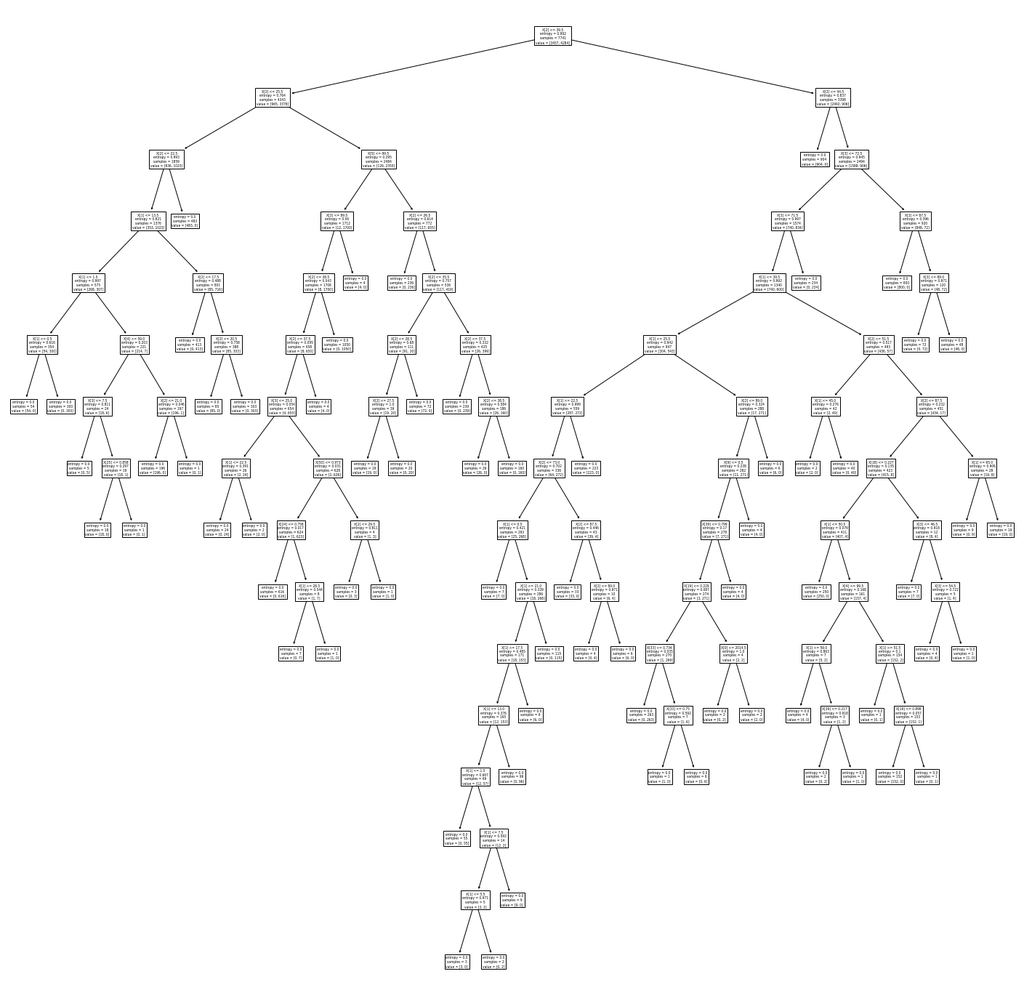

```python
print("\n\n\nThe decision tree of maximum depth:")
plt.figure(figsize=(25,25))
tree.plot_tree(dtree);
```

### Tuning hyper-parameters

In this part I tuned and optimizing the parapeters max_depth and min_samples_split using `GridSearchCV()` method in scikit-learn library.

```python
parameters = {'max_depth': list(range(1, 20)), 'min_samples_split': list(range(2, 8))}
dtree = GridSearchCV(estimator = DecisionTreeClassifier(random_state = 100), param_grid = parameters, scoring = 'accuracy',\
                     verbose = 0, cv = 3);

dtree.fit(X_train, y_train);
test_pred = dtree.predict(X_test);
train_pred = dtree.predict(X_train);
test_accuracy = metrics.accuracy_score(y_test, test_pred);
train_accuracy = metrics.accuracy_score(y_train, train_pred);
print(f"test accuracy: {test_accuracy}")
print(f"train accuracy: {train_accuracy}")
print(f"best parameter: {dtree.best_params_}")
```

```
test accuracy: 0.9885473176612417
train accuracy: 0.9989665417904664
best parameter: {'max_depth': 15, 'min_samples_split': 2}
```

### Part 1

First I explane the basic concept of Overfitting and Underfitting in machine learning:

- **Overfitting:** If our model does much better on the training set than on the test set, then we’re likely overfitting. Overfitting happens when a model learns the detail and noise in the training data to the extent that it negatively impacts the performance of the model on new data. This means that the noise or random fluctuations in the training data is picked up and learned as concepts by the model. The problem is that these concepts do not apply to new data and negatively impact the models ability to generalize.
- **Underfitting:** Underfitting refers to a model that can neither model the training data nor generalize to new data.An underfit machine learning model is not a suitable model and will be obvious as it will have poor performance on the training data.

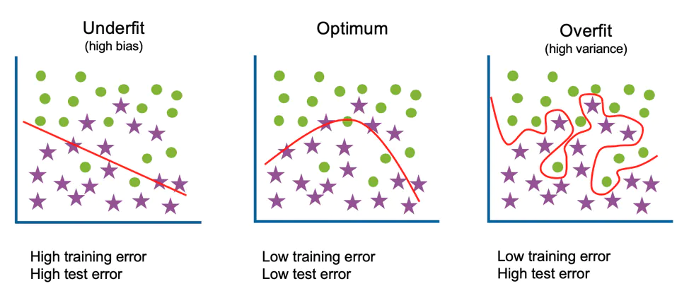

### Ratio of Train & Test Data

Generally, it is common knowledge that too little training data, results in a poor approximation. An over-constrained model will underfit the small training dataset, whereas an under-constrained model, in turn, will likely overfit the training data, both resulting in poor performance. Too little test data will result in an optimistic and high variance estimation of model performance.

After seraching and reading some researches, I chose 70% for train set and 30% percent for test set. I got good results till now.

When we have **98%** of the set as train and just 2% for test set, it is likely to cause overfitting because our model learns the detail and noise in the training data to the extent that it negatively impacts the performance of the model on new data.

When we have **40%** of the set as train and just 60% for test set, it is likely to cause underfitting because our model is not trained well so it would not get good results neither on train set not on test set.

*Note that in the given dataset in this project, the overfitting and underfitting is not clear beacuse of the high correlation between genres and the target column.

### 98% Train, 2% Test Set

```python
X_train, X_test, y_train, y_test = train_test_split(X, y, test_size = 0.02, random_state = 100)
dtree = tree.DecisionTreeClassifier(criterion='entropy', max_depth = 7, random_state = 100)
dtree.fit(X_train, y_train)
test_pred = dtree.predict(X_test)
train_pred = dtree.predict(X_train)
test_accuracy = metrics.accuracy_score(y_test, test_pred);
train_accuracy = metrics.accuracy_score(y_train, train_pred);
print("Result for minimum depth:")
print(f"test accuracy: {test_accuracy*100:.5f}%")
print(f"train accuracy: {train_accuracy*100:.5f}%")
print(confusion_matrix(y_test, test_pred))
```

```
Result for minimum depth:
test accuracy: 97.74775%
train accuracy: 98.63431%
[[ 97   5]
 [  0 120]]
```

### 40% Train, 60% Test Set

```python
X_train, X_test, y_train, y_test = train_test_split(X, y, test_size = 0.6, random_state = 100)
dtree = tree.DecisionTreeClassifier(criterion='entropy', max_depth = 7, random_state = 100)
dtree.fit(X_train, y_train)
test_pred = dtree.predict(X_test)
train_pred = dtree.predict(X_train)
test_accuracy = metrics.accuracy_score(y_test, test_pred);
train_accuracy = metrics.accuracy_score(y_train, train_pred);
print("Result for minimum depth:")
print(f"test accuracy: {test_accuracy*100:.5f}%")
print(f"train accuracy: {train_accuracy*100:.5f}%")
print(confusion_matrix(y_test, test_pred))
```

```
Result for minimum depth:
test accuracy: 97.43822%
train accuracy: 97.73909%
[[2805  150]
 [  20 3661]]
```

```python
X_train, X_test, y_train, y_test = train_test_split(X, y, test_size = 0.3, random_state = 100)
```

## Part 2

### Study Effect of Depth on Accuracy

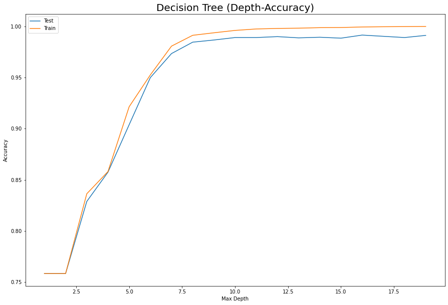

```python
train_acc = []
test_acc = []
for i in range(1,20):
    dtree = tree.DecisionTreeClassifier(max_depth = i, random_state = 100)
    dtree.fit(X_train, y_train)
    test_pred = dtree.predict(X_test);
    train_pred = dtree.predict(X_train);
    test_acc.append(metrics.accuracy_score(y_test, test_pred));
    train_acc.append(metrics.accuracy_score(y_train, train_pred));


fig = plt.figure()
fig.set_figheight(10)
fig.set_figwidth(15)
plt.plot(list(range(1, 20)), test_acc, label='Test')
plt.plot(list(range(1, 20)), train_acc, label='Train')
plt.ylabel('Accuracy')
plt.xlabel('Max Depth')
plt.title('Decision Tree (Depth-Accuracy)', fontsize=20)
plt.legend()
plt.show()
```

As we can see in the plot, by **increasing** max depth the accuracy **increases** too till around the max depth of 10 where accuracy get stable and is 1.

## Phase 3: Predicting by Ensembling Methods

### Random forest:

Random forest is a Supervised Machine Learning Algorithm that is used widely in Classification and Regression problems. It builds decision trees on different samples and takes their majority vote for classification and average in case of regression.

Here I implemented the random forest model by `RandomForestClassifier()` method in the sklearn library.

```python
random_forest = RandomForestClassifier(n_estimators = 10, criterion='entropy', random_state = 100)
random_forest.fit(X_train, y_train)
random_forest_test_pred = random_forest.predict(X_test);
random_forest_train_pred = random_forest.predict(X_train);
random_forest_test_accuracy = metrics.accuracy_score(y_test, random_forest_test_pred);
random_forest_train_accuracy = metrics.accuracy_score(y_train, random_forest_train_pred);
print(f"test accuracy: {random_forest_test_accuracy}")
print(f"train accuracy: {random_forest_train_accuracy}")
```

```
test accuracy: 0.9807112718505123
train accuracy: 0.9996124531714249
```

### Confusion Matrix & Max Depth

```python
random_forest = RandomForestClassifier(criterion='entropy', random_state = 100)
random_forest.fit(X_train, y_train)
random_forest_test_pred = random_forest.predict(X_test);
random_forest_train_pred = random_forest.predict(X_train);
random_forest_test_accuracy = metrics.accuracy_score(y_test, random_forest_test_pred);
random_forest_train_accuracy = metrics.accuracy_score(y_train, random_forest_train_pred);
print("Result for maximum depth:")
print(f"test accuracy: {random_forest_test_accuracy}")
print(f"train accuracy: {random_forest_train_accuracy}")
print(confusion_matrix(y_test, random_forest_test_pred))
print("=======")
random_forest = RandomForestClassifier(criterion='entropy', max_depth = 3, random_state = 100)
random_forest.fit(X_train, y_train)
random_forest_test_pred = random_forest.predict(X_test);
random_forest_train_pred = random_forest.predict(X_train);
random_forest_test_accuracy = metrics.accuracy_score(y_test, random_forest_test_pred);
random_forest_train_accuracy = metrics.accuracy_score(y_train, random_forest_train_pred);
print("Result for medium depth:")
print(f"test accuracy: {random_forest_test_accuracy}")
print(f"train accuracy: {random_forest_train_accuracy}")
print(confusion_matrix(y_test, random_forest_test_pred))
print("=======")
random_forest = RandomForestClassifier(criterion='entropy', max_depth = 1, random_state = 100)
random_forest.fit(X_train, y_train)
random_forest_test_pred = random_forest.predict(X_test);
random_forest_train_pred = random_forest.predict(X_train);
random_forest_test_accuracy = metrics.accuracy_score(y_test, random_forest_test_pred);
random_forest_train_accuracy = metrics.accuracy_score(y_train, random_forest_train_pred);
print("Result for minimum depth:")
print(f"test accuracy: {random_forest_test_accuracy}")
print(f"train accuracy: {random_forest_train_accuracy}")
print(confusion_matrix(y_test, random_forest_test_pred))
```

```
Result for maximum depth:
test accuracy: 0.9906570223025919
train accuracy: 1.0
[[1458   13]
 [  18 1829]]
=======
Result for medium depth:
test accuracy: 0.7992766726943942
train accuracy: 0.8082935021315075
[[ 997  474]
 [ 192 1655]]
=======
Result for minimum depth:
test accuracy: 0.7172995780590717
train accuracy: 0.7272962149593076
[[ 693  778]
 [ 160 1687]]
```

### Tuning hyper-parameters

```python
hyper_parameters = {'n_estimators':list(range(5, 101, 100)), 'max_depth': list(range(2, 25, 1)), 'min_samples_split': list(range(2, 10))}
random_forest = GridSearchCV(estimator = RandomForestClassifier(random_state = 100), param_grid=hyper_parameters, verbose = 0, cv = 3);
random_forest.fit(X_train, y_train)
random_forest_test_pred = random_forest.predict(X_test);
random_forest_train_pred = random_forest.predict(X_train);
random_forest_test_accuracy = metrics.accuracy_score(y_test, random_forest_test_pred);
random_forest_train_accuracy = metrics.accuracy_score(y_train, random_forest_train_pred);
print(f"test accuracy: {random_forest_test_accuracy}")
print(f"train accuracy: {random_forest_train_accuracy}")
print(f"best parameter: {random_forest.best_params_}")
```

```
test accuracy: 0.9668474984930681
train accuracy: 0.990311329285622
best parameter: {'max_depth': 24, 'min_samples_split': 5, 'n_estimators': 5}
```

Here I study the effect of **Max Depth** and **Number of Estimators** on **Accuracy** in random forest model.

### Study Effect of Depth on Accuracy

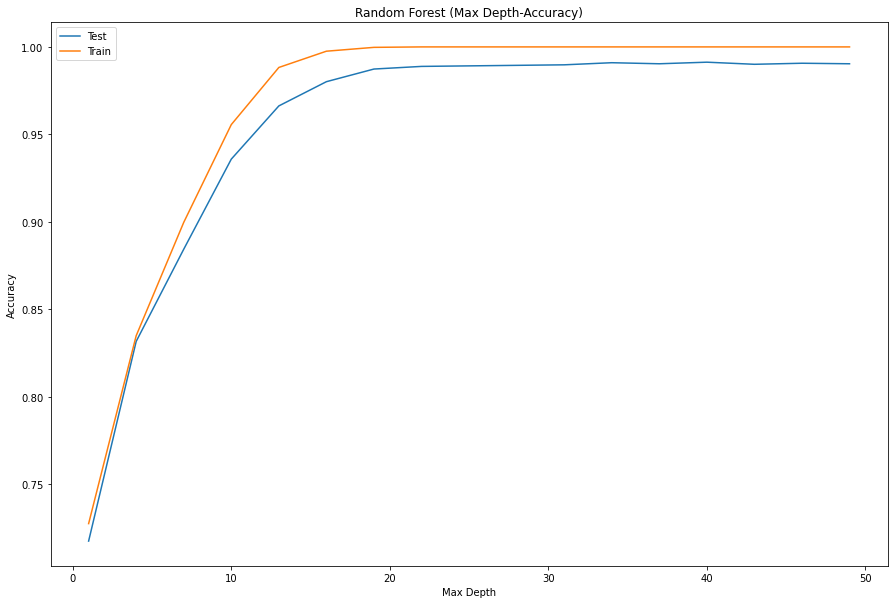

```python
random_forest_train_acc = []
random_forest_test_acc = []
for i in range(1,50, 3):
    random_forest = RandomForestClassifier(criterion='entropy', max_depth = i, random_state = 100)
    random_forest.fit(X_train, y_train)
    random_forest_test_pred = random_forest.predict(X_test);
    random_forest_train_pred = random_forest.predict(X_train);
    random_forest_test_acc.append(metrics.accuracy_score(y_test, random_forest_test_pred));
    random_forest_train_acc.append( metrics.accuracy_score(y_train, random_forest_train_pred));


fig = plt.figure()
fig.set_figheight(10)
fig.set_figwidth(15)
plt.plot(list(range(1, 50, 3)), random_forest_test_acc, label='Test')
plt.plot(list(range(1, 50, 3)), random_forest_train_acc, label='Train')
plt.ylabel('Accuracy')
plt.xlabel('Max Depth')
plt.title('Random Forest (Max Depth-Accuracy)')
plt.legend()
plt.show()
```

### Study Effect of Number of Estimators on Accuracy

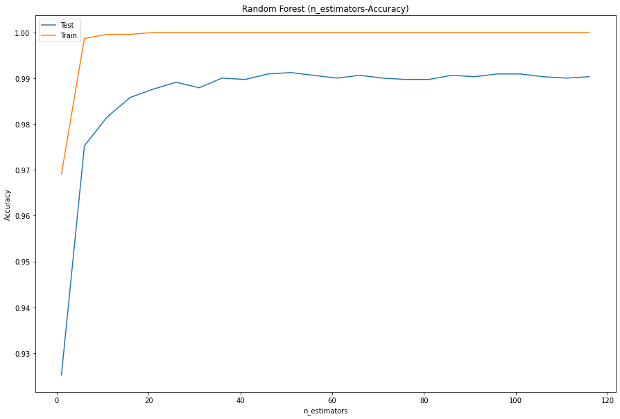

```python
random_forest_train_acc = []
random_forest_test_acc = []
for i in range(1, 120, 5):
    random_forest = RandomForestClassifier(criterion='entropy', n_estimators = i, random_state = 100)
    random_forest.fit(X_train, y_train)
    random_forest_test_pred = random_forest.predict(X_test);
    random_forest_train_pred = random_forest.predict(X_train);
    random_forest_test_acc.append(metrics.accuracy_score(y_test, random_forest_test_pred));
    random_forest_train_acc.append( metrics.accuracy_score(y_train, random_forest_train_pred));


fig = plt.figure()
fig.set_figheight(10)
fig.set_figwidth(15)
plt.plot(list(range(1, 120, 5)), random_forest_test_acc, label='Test')
plt.plot(list(range(1, 120, 5)), random_forest_train_acc, label='Train')
plt.ylabel('Accuracy')
plt.xlabel('n_estimators')
plt.title('Random Forest (n_estimators-Accuracy)')
plt.legend()
plt.show()
```

## Variance & Bias

Both bias and variance are forms of prediction error in machine learning.Typically, we can reduce error from bias but might increase error from variance as a result, or vice versa.

**Bias:** Bias are the simplifying assumptions made by a model to make the target function easier to learn. Generally, linear algorithms have a high bias making them fast to learn and easier to understand but generally less flexible. In turn, they have lower predictive performance on complex problems that fail to meet the simplifying assumptions of the algorithms bias. Bias is the difference between the average prediction of our model and the correct value which we are trying to predict. Model with high bias pays very little attention to the training data and oversimplifies the model. It always leads to high error on training and test data.

**Variance:** Variance is the amount that the estimate of the target function will change if different training data was used. Variance is the variability of model prediction for a given data point or a value which tells us spread of our data. Model with high variance pays a lot of attention to training data and does not generalize on the data which it hasn’t seen before. As a result, such models perform very well on training data but has high error rates on test data.

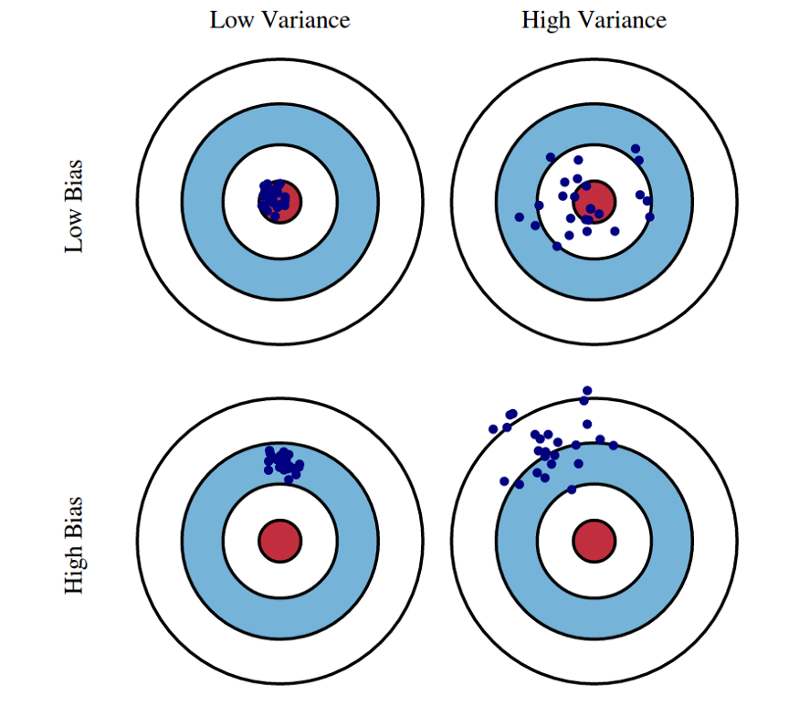

**Bias Variance in Random Forest**

The Mean Squared Error (MSE) of a statistical model can be expressed as the sum of the squared bias of its predictions, the variance of those predictions, and the variance of some error term 𝜖. Since both squared bias and variance are non-negative, and 𝜖, which captures randomness in the data, is beyond our control, we minimize MSE by minimizing the variance and bias of our model. I have found the image in Fig. 1 to be particularly good at illustrating what the two terms mean.

### Bias & Variance Trade-off

If our model is too simple and has very few parameters then it may have high bias and low variance. On the other hand if our model has large number of parameters then it’s going to have high variance and low bias. So we need to find the right/good balance without overfitting and underfitting the data.

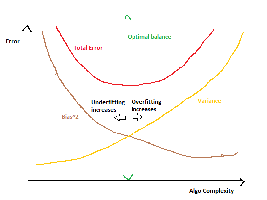

### Bias vs Variance: Random Forest and Decision Tree

Random forests, are a powerful modelling tool that is far more resilient than a single decision tree. They combine numerous decision trees to reduce overfitting and bias-related inaccuracy. Random Forests tend to produce a better model than just a single decision tree. The main idea behind random forest is that lots of high variance and low bias trees combine to generate a low bias low variance forest. Since it is distibuted over different trees and each tree sees different set of data , therefore random forest in general do not over fit. And since they are made of low bias trees, underfitting also does not happen.

To Sum up:

Variance: Random Forest < Decision Tree

Bias: Random Forest < Decision Tree,